```r
library(tidyverse)
```

I will explore the data Harvard researchers used to write following article in Scientific Reports, “The Cannabinoid Content of Legal Cannabis in Washington State Varies Systematically Across Testing Facilities and Popular Consumer Products”

### Link to data and related information

[Harvard cannabis measurement study](https://dataverse.harvard.edu/dataset.xhtml?persistentId=doi:10.7910/DVN/E8TQSD)

### Abstract

> The majority of adults in the U.S. now have state-legal access to medical or recreational cannabis products, despite their federal prohibition. Given the wide array of pharmacologically active compounds in these products, it is essential that their biochemical profile is measured and reported to consumers, which requires accurate laboratory testing. However, no universal standards for laboratory testing protocols currently exist, and there is controversy as to whether all reported results are legitimate. To investigate these concerns, we analyzed a publicly available seed-to-sale traceability dataset from Washington state containing measurements of the cannabinoid content of legal cannabis products from state-certified laboratories. Consistent with previous work, we found that commercial Cannabisstrains fall into three broad chemotypes defined by the THC:CBD ratio. Moreover, we documented systematic differences in the cannabinoid content reported by different laboratories, relative stability in cannabinoid levels of commercial flower and concentrates over time, and differences between popular commercial strains. Importantly, interlab differences in cannabinoid reporting persisted even after controlling for plausible confounds. Our results underscore the need for standardized laboratory methodologies in the legal cannabis industry and provide a framework for quantitatively assessing laboratory quality.

### Sources used to create the dataset:

This dataset comes from the Harvard Dataset organization and comprises of Washington’s LCB i502 Recreational Cannabis testing data from June 2014 to May 2017 as well as some data from Leafly strain in 2018.

```r
data <- read_csv("Replication_Data.csv")
head(data)
```

```
## # A tibble: 6 x 22
##   test_id test_strain leafly_strain no_match thc_max cbd_max date_test
##     <dbl> <chr>       <chr>            <dbl>   <dbl>   <dbl> <chr>
## 1      19 Dutch Hawa… dutch-hawaii…        0   20.1     0.54 6/19/201…
## 2      20 Shiska Ber… shishkaberry         0   13.5     0    6/19/201…
## 3      21 Sleestack   sleestack            0    9.91    0    6/19/201…
## 4      22 Space Need… <NA>                 1   10.8     0    6/19/201…
## 5      23 Double Pur… double-purpl…        0   11.7     0    6/20/201…
## 6      24 FLOG A      flo-og               0   16.8     0.01 6/24/201…
## # … with 15 more variables: year <dbl>, org_name <chr>, org_active <dbl>,
## #   lab_name <chr>, inventory_type <chr>, chemotype <dbl>,
## #   strain_category <chr>, strain_leafly_page_rank <dbl>,
## #   strain_leafly_review_rank <dbl>, strain_tests <dbl>,
## #   strain_chemotype <dbl>, strain_prop_chemotype1 <dbl>,
## #   strain_prop_chemotype2 <dbl>, strain_prop_chemotype3 <dbl>,
## #   strain_modal_chemo_prop <dbl>
```

### Questions I Can Answer:

1.Plot top ten test_strains with highest level of THC and top ten strains with highest level of CBD.

2.Plot different THC levels in different strain_categories and plot different CBD levels in different strains.

3.What are the top two labs that produces the highest levels of THC and CBD?

4.What are the top six organizations that produces the highest levels of THC and CBD?

### Data Quality Issues:

One data quality issue I will face is there are many missing values in the strain_category column as these tests did not match to a Leafy strain. This can be solved by using the na.rm = TRUE argument while conducting my tests and analyses.

Another data quality issue I will face is that some of the strains in the test_strain column repeat causing multiple values of thc_max or cbd_max for one test_strain. I can use the unique() argument to help with this.

### Data Analysis Questions

1.Top ten test_strains with highest level of THC and top ten strains with highest level of CBD. Plot them.

```r
#THC
highTHCten <- arrange(data,desc(thc_max))%>%
  select(test_strain,thc_max)%>%
  top_n(10)
highTHCten
```

```
## # A tibble: 12 x 2
##    test_strain    thc_max
##    <chr>            <dbl>
##  1 Jilly Dream        100
##  2 Dutch Treat        100
##  3 Onion Creek        100
##  4 Mixed              100
##  5 Mixed              100
##  6 Mixed              100
##  7 Mixed              100
##  8 Mixed              100
##  9 UW Purple Kush     100
## 10 Mixed              100
## 11 Mixed              100
## 12 Cheddar Head       100
```

```r
#In finding the top ten_strains with the highest levels of THC, I have noticed that some of the strains have the maximum level of 100. I will make a new output with all of these strains, rather than just the top ten.

highTHC <- filter(data,thc_max == 100)%>%
  select(test_strain,thc_max)

count(highTHC)
```

```
## # A tibble: 1 x 1
##       n
##   <int>
## 1    12
```

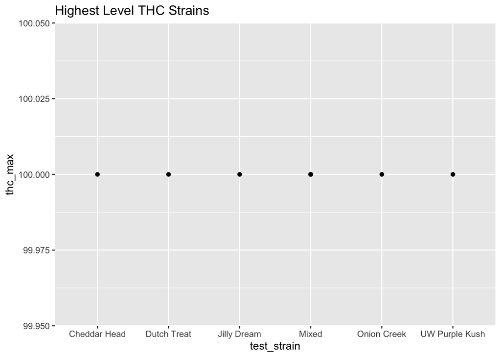

```r
highTHC <- filter(data,thc_max == 100)%>%
  select(test_strain,thc_max)%>%
  unique

#From this I have discovered that there are 12 test_strains in the list with the highest THC level, and without duplicates there are 6.

ggplot(highTHCten, aes(x = test_strain,y = thc_max)) + geom_point() +
  ggtitle(label = "Highest Level THC Strains")
```

```r
#CBD
highCBD <- arrange(data,desc(cbd_max))%>%
  select(test_strain,cbd_max)%>%
  top_n(10)
highCBD
```

```
## # A tibble: 10 x 2
##    test_strain     cbd_max
##    <chr>             <dbl>
##  1 AC/DC              97.0
##  2 Sour Tsunami #3    95.2
##  3 Ozma               93.5
##  4 Harle-Tsu          92.8
##  5 AC/DC              92.4
##  6 Yummy              91.6
##  7 AC/DC              91.6
##  8 Sour Tsunami       91.2
##  9 AC/DC              91.1
## 10 Sour Amnesia       89.3
```

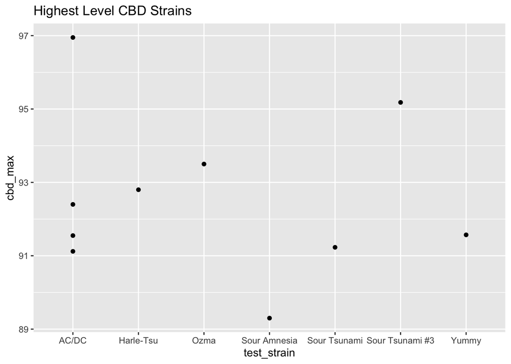

```r
#For CBD, none of the strands had level 100 of CBD as did THC. The highest level here is 96.95.

ggplot(highCBD, aes(x = test_strain,y = cbd_max)) + geom_point() +
  ggtitle(label = "Highest Level CBD Strains")
```

```r
allHighTHC <- filter(data,thc_max > 80)%>%
  select(test_strain)
count(allHighTHC)
```

```
## # A tibble: 1 x 1
##       n
##   <int>
## 1  6596
```

```r
allHighCBD <- filter(data,cbd_max > 80)%>%
  select(test_strain)
count(allHighCBD)
```

```
## # A tibble: 1 x 1
##       n
##   <int>
## 1    30
```

```r
summary(highTHCten)
```

```
##  test_strain           thc_max
##  Length:12          Min.   :100
##  Class :character   1st Qu.:100
##  Mode  :character   Median :100
##                     Mean   :100
##                     3rd Qu.:100
##                     Max.   :100
```

```r
summary(highCBD)
```

```
##  test_strain           cbd_max
##  Length:10          Min.   :89.30
##  Class :character   1st Qu.:91.31
##  Mode  :character   Median :91.98
##                     Mean   :92.56
##                     3rd Qu.:93.33
##                     Max.   :96.95
```

2.Plot different total THC levels in different strain_categories and plot different total CBD levels in different strains.

```r
indicaTHC <- filter(data, strain_category == "Indica")%>%
  top_n(50) %>%
  select(thc_max) %>%
  sum
indicaCBD <- filter(data, strain_category == "Indica")%>%
  top_n(50) %>%
  select(cbd_max) %>%
  sum
sativaTHC <- filter(data, strain_category == "Sativa")%>%
  top_n(50) %>%
  select(thc_max) %>%
  sum
sativaCBD <- filter(data, strain_category == "Sativa")%>%
  top_n(50) %>%
  select(cbd_max) %>%
  sum
hybridTHC <- filter(data, strain_category == "Hybrid")%>%
  top_n(50) %>%
  select(thc_max) %>%
  sum
hybridCBD <- filter(data, strain_category == "Hybrid")%>%
  top_n(50) %>%
  select(cbd_max) %>%
  sum
strainCategories = c("Indica","Sativa","Hybrid")
thcLevels = c(indicaTHC,sativaTHC,hybridTHC)

dataTHC <- data.frame("Strain Categories" = strainCategories,"THC Levels" = thcLevels)
head(dataTHC)
```

```
##   Strain.Categories THC.Levels
## 1            Indica   321272.0
## 2            Sativa   215796.6
## 3            Hybrid   734108.4
```

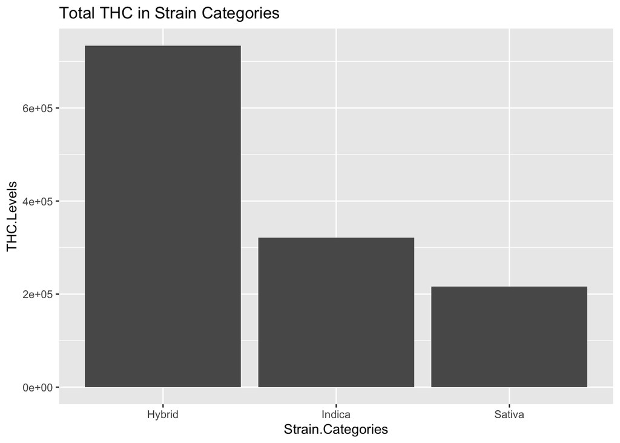

```r
ggplot(dataTHC, aes(x = Strain.Categories, y = THC.Levels)) + geom_bar(stat="identity") + ggtitle(label = "Total THC in Strain Categories")
```

```r
cbdLevels = c(indicaCBD,sativaCBD,hybridCBD)

dataCBD <- data.frame("Strain Categories" = strainCategories,"CBD Levels" = cbdLevels)
head(dataCBD)
```

```
##   Strain.Categories CBD.Levels
## 1            Indica   3354.691
## 2            Sativa   2451.834
## 3            Hybrid   7722.891
```

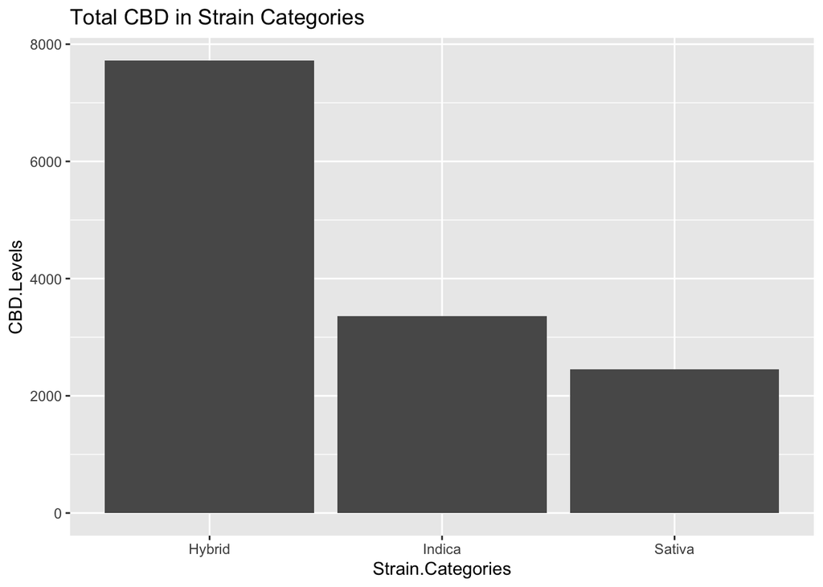

```r
ggplot(dataCBD, aes(x = Strain.Categories, y = CBD.Levels)) + geom_bar(stat="identity") + ggtitle(label = "Total CBD in Strain Categories")
```

```r
summary(dataTHC)
```

```
##  Strain.Categories   THC.Levels
##  Hybrid:1          Min.   :215797
##  Indica:1          1st Qu.:268534
##  Sativa:1          Median :321272
##                    Mean   :423726
##                    3rd Qu.:527690
##                    Max.   :734108
```

```r
summary(dataCBD)
```

```
##  Strain.Categories   CBD.Levels
##  Hybrid:1          Min.   :2452
##  Indica:1          1st Qu.:2903
##  Sativa:1          Median :3355
##                    Mean   :4510
##                    3rd Qu.:5539
##                    Max.   :7723
```

For this question, I took the top 50 highest levels of THC and CBD for each strain category and added them together to get the total THC and CBD level for each strain category. I was then able to compare the different strain categories to each other in terms of their total THC and CBD levels. I discovered that the THC levels were much higher than the CBD levels overall. I also discovered that for both THC and CBD, the categories went from hybrid to indica to sativa in terms of greatest to least total amount. This makes it seem that the strain category of sativa always has the lowest amount of CBD and THC, while indica has the second highest amount, and hybrid always has the highest. Looking at the data summaries, it looks like the minimum total THC level is 215797 and the maximum is 734108, while the minimum CBD level is 2452 and the maximum is 7723, showing how they represent extremely different amounts.

3.What are the top two labs that produces the highest levels of THC and CBD?

```r
highTHClab <- arrange(data,desc(thc_max))%>%
  select(lab_name,thc_max)%>%
  unique%>%
  top_n(2)
head(highTHClab)
```

```
## # A tibble: 2 x 2
##   lab_name             thc_max
##   <chr>                  <dbl>
## 1 Green Grower Labs        100
## 2 Testing Technologies     100
```

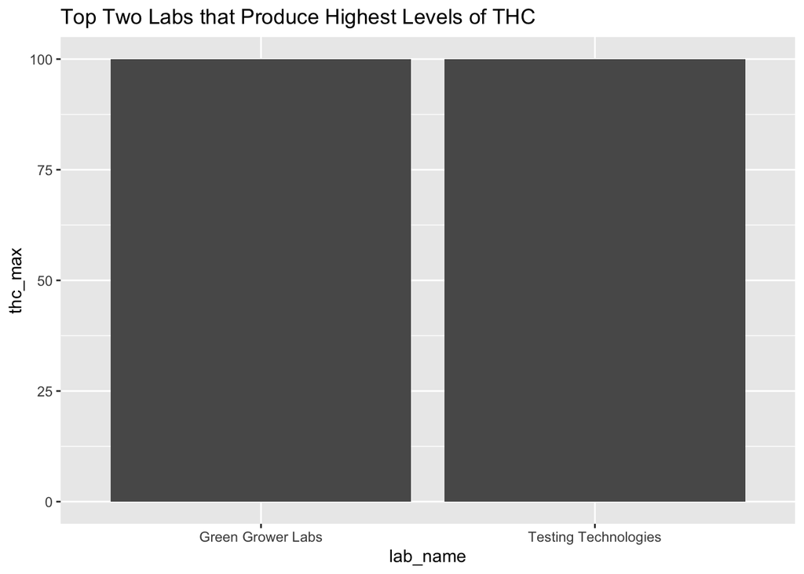

```r
ggplot(highTHClab, aes(x = lab_name, y = thc_max)) + geom_bar(stat="identity") + ggtitle(label = "Top Two Labs that Produce Highest Levels of THC")
```

```r
highCBDlab <- arrange(data,desc(cbd_max))%>%
  select(lab_name,cbd_max)%>%
  top_n(2)
head(highCBDlab)
```

```
## # A tibble: 2 x 2
##   lab_name        cbd_max
##   <chr>             <dbl>
## 1 Integrity Labs     97.0
## 2 Trace Analytics    95.2
```

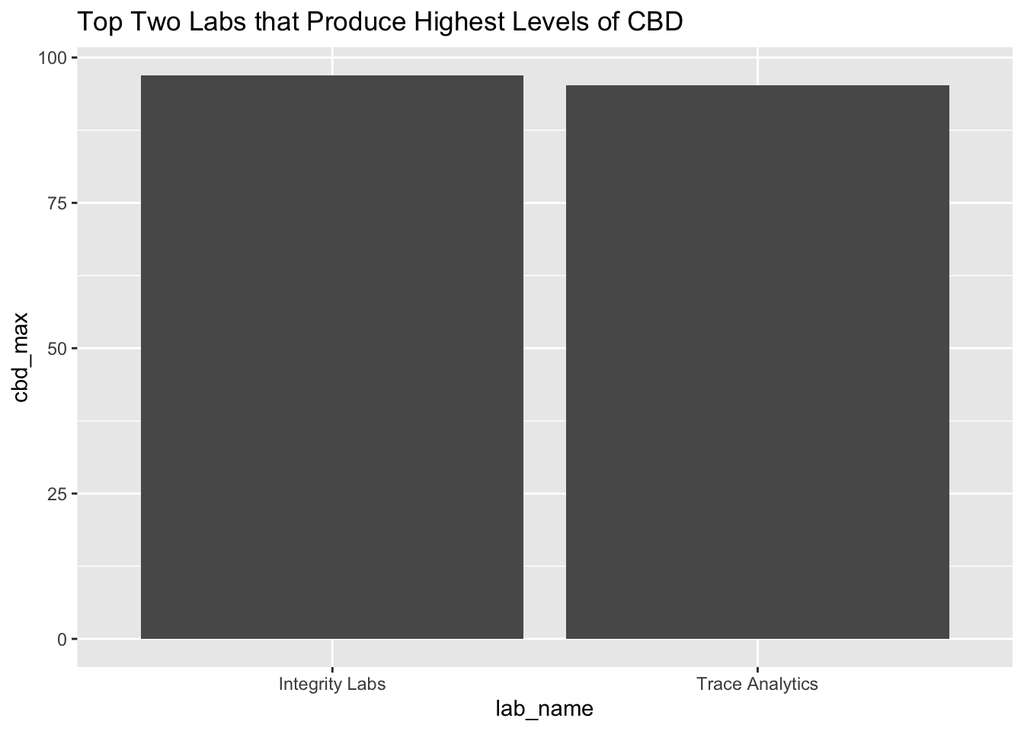

```r
ggplot(highCBDlab, aes(x = lab_name, y = cbd_max)) + geom_bar(stat="identity") + ggtitle(label = "Top Two Labs that Produce Highest Levels of CBD")
```

```r
summary(highTHClab)
```

```
##    lab_name            thc_max
##  Length:2           Min.   :100
##  Class :character   1st Qu.:100
##  Mode  :character   Median :100
##                     Mean   :100
##                     3rd Qu.:100
##                     Max.   :100
```

```r
summary(highCBDlab)
```

```
##    lab_name            cbd_max
##  Length:2           Min.   :95.18
##  Class :character   1st Qu.:95.62
##  Mode  :character   Median :96.06
##                     Mean   :96.06
##                     3rd Qu.:96.51
##                     Max.   :96.95
```

4.What are the top six organizations that produces the highest levels of THC and CBD?

```r
highTHCorg<- arrange(data,desc(thc_max))%>%
  select(org_name,thc_max)%>%
  unique%>%
  top_n(6)
```

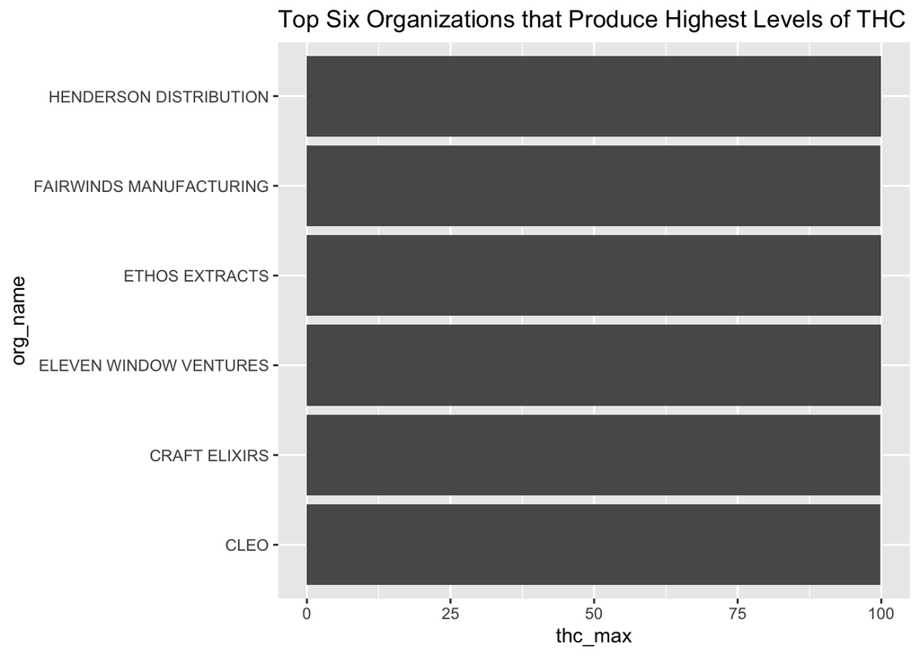

```r
ggplot(highTHCorg, aes(x = org_name, y = thc_max)) + geom_bar(stat="identity") + ggtitle(label = "Top Six Organizations that Produce Highest Levels of THC") + coord_flip()
```

```r
highCBDorg <- arrange(data,desc(cbd_max))%>%
  select(org_name,cbd_max)%>%
  top_n(6)
```

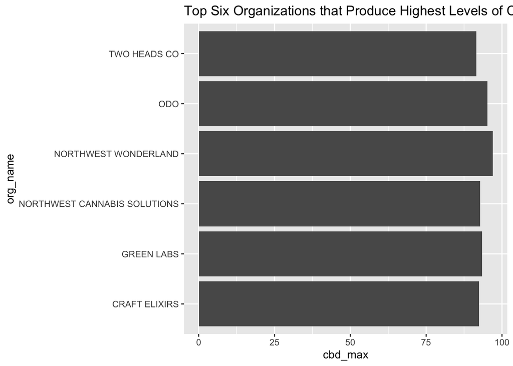

```r
ggplot(highCBDorg, aes(x = org_name, y = cbd_max)) + geom_bar(stat="identity") + ggtitle(label = "Top Six Organizations that Produce Highest Levels of CBD") + coord_flip()
```

```r
summary(highTHCorg)
```

```
##    org_name            thc_max
##  Length:6           Min.   : 99.78
##  Class :character   1st Qu.: 99.82
##  Mode  :character   Median : 99.94
##                     Mean   : 99.91
##                     3rd Qu.:100.00
##                     Max.   :100.00
```

```r
summary(highCBDorg)
```

```
##    org_name            cbd_max
##  Length:6           Min.   :91.57
##  Class :character   1st Qu.:92.50
##  Mode  :character   Median :93.15
##                     Mean   :93.73
##                     3rd Qu.:94.76
##                     Max.   :96.95
```

I was able to successfully determine the top six organizations that produce the highest levels of THC and CBD. The top six organizations that produced the highest levels of THC were Henderson Distribution, Eleven Window Ventures, Ethos Extracts, Fairwinds Manufacturing, Craft Elixers, and Cleo. The top six organizations that produced the highest levels of CBD were Northwest Wonderland, Odo, Green Labs, Northwest Cannabis Solutions, Craft Elixers, and Two Heads Co. Here again we see that the top THC producing organizations produced at levels close to 100, whereas the top CBD producing organizations produced at levels closer to 95, and with more variability as it ranges from 91.57 to 96.95, whereas for THC it only ranges from 99.78 to 100.00.